# Convergence in Distribution

Paul Schrimpf

2025-10-27

# Convergence in Distribution

## Reading

- Required: **Song (2021) chapter 10**

$$\def\Er{{\mathrm{E}}}
\def\En{{\mathbb{En}}}
\def\cov{{\mathrm{Cov}}}
\def\var{{\mathrm{Var}}}
\def\R{{\mathbb{R}}}
\newcommand\norm[1]{\left\lVert#1\right\rVert}
\def\rank{{\mathrm{rank}}}
\newcommand{\inpr}{ \overset{p^*_{\scriptscriptstyle n}}{\longrightarrow}}
\def\inprob{{\,{\buildrel p \over \rightarrow}\,}}
\def\indist{\,{\buildrel d \over \rightarrow}\,}
\DeclareMathOperator*{\plim}{plim}$$

## Convergence in Distribution

**Definition**

Random vectors $X_1, X_2, ...$ **converge in distribution** to the random vector $X$ if for all $f \in \underbrace{\mathcal{C}_b}$ (continuous and bounded)
$$\Er[ f(X_n) ] \to \Er[f(X)]$$
denoted by $X_n \indist X$

## Relation to Convergence in Probability

**Theorem 1.4**

1. If $X_n \indist X$, then $X_n = O_p(1)$
2. If $c$ is a constant, then $X_n \inprob c$ iff $X_n \indist c$
3. If $Y_n \inprob c$ and $X_n \indist X$, then $(Y_n, X_n) \indist (c, X)$
4. If $X_n \inprob X$, then $X_n \indist X$

## Slutsky’s Lemma

**Theorem 1.5 (Generalized Slutsky’s Lemma)**

If $Y_n \inprob c$, $X_n \indist X$, and $g$ is continuous, then
$$g(Y_n, X_n) \indist g(c,X)$$

- Implies:
  - $Y_n + X_n \indist c + X$
  - $Y_n X_n \indist c X$
  - $X_n/Y_n \indist X/c$

# Central Limit Theorem

## Levy’s Continuity Theorem

**Lemma 2.1 (Levy’s Continuity Theorem)**

$X_n \indist X$ iff $\Er[e^{i t'X_n} ] \to \Er[e^{i t' X} ]$ for all $t \in \R^d$

- see Döbler (2022) for a short proof
- $\Er[e^{i t' X}] \equiv \varphi(t)$ is the **characteristic function** of $X$

## Law of Large Numbers Revisited

**Lemma 2.2 (Weak Law of Large Numbers)**

If $X_1, ..., X_n$ are i.i.d. with $\Er[|X_1|] < \infty$, then $\frac{1}{n} \sum_{i=1}^n X_i \inprob \Er[X_1]$

**Theorem 2.2 (non-iid WLLN)**

If $\Er[X_i]=0$, $\Er[X_i X_j] = 0$ for all $i \neq j$ and $\frac{1}{n} \max_{1 \leq j \leq n} \Er[X_j^2] \to 0$, then $\frac{1}{n} \sum_{i=1}^n X_i \inprob 0$

## Central Limit Theorem

**Theorem 2.3**

Suppose $X_1, ..., X_n \in \R$ are i.i.d. with $\Er[X_1] = \mu$ and $\var(X_1) = \sigma^2$, then
$$\frac{1}{\sqrt{n}} \sum_{i=1}^n \frac{X_i - \mu}{\sigma} \indist N(0,1)$$

```julia
using PlotlyLight, Distributions, Statistics
function simulateCLT(n, s, dist=Uniform())
  μ = mean(dist)
  σ = sqrt(var(dist))
  x = rand(dist, n, s)
  z = 1/sqrt(n)*sum( (x .- μ)./σ, dims=1)
end
dist = Uniform()
x = range(-2.5, 2.5, length=200)
N = [1, 2, 4, 16, 256]
S = 10_000
Fn = [let z=simulateCLT(n,S, dist);
    x->mean(z .<= x)
      end for n in N];
```

## CDF

**plotting code**

```julia
plt = Plot()
plt.layout = Config()
for i in axes(N)[1]
  plt(x=x, y=Fn[i].(x), name="N=$(N[i])")
end
plt(x=x, y=cdf.(Normal(),x), name="Normal CDF")
fig = plt()
fig
```

[output not shown]

## Size Distortion

**plotting code**

```julia
p = range(0,1,length=200)
plt = Plot()
plt.layout = Config()
plt.layout.yaxis.title.text="p - Fn(Φ^{-1}(p))"
plt.layout.xaxis.title.text="p"
for i in axes(N)[1]
  plt(x=p,y=p - Fn[i].(quantile.(Normal(),p)), name="N=$(N[i])")
end
fig = plt()
fig
```

[output not shown]

## Histogram

**plotting code**

```julia
bins = range(-2.5,2.5,length=21)
x = range(-2.5,2.5, length=1000)
plt = Plot();
plt.layout=Config()
function Hn(x, F)
  if (x <= bins[1] || x>bins[end])
    return 0.0
  end
  j = findfirst( x .<= bins )
  return (F(bins[j]) - F(bins[j-1]))
end
plt(x=x,y=Hn.(x,x->cdf(Normal(),x)), name="Normal")
for i in axes(N)[1]
  plt(x=x,y=Hn.(x, Fn[i]), name="N=$(N[i])")
end
fig = plt()
fig
```

[output not shown]

## Cramér-Wold Device

**Lemma 2.2**

For $X_n, X \in \R^d$, $X_n \indist X$ iff $t' X_n \indist t' X$ for all $t \in \R^d$

## Multivariate Central Limit Theorem

**Theorem 2.4**

Suppose $X_1, ..., X_n$ are i.i.d. with $\Er[X_1] = \mu \in \R^d$ and $\var(X_1) = \Sigma > 0$, then
$$\frac{1}{\sqrt{n}} \sum_{i=1}^n (X_i - \mu) \indist N(0,\Sigma)$$

## Delta Method

**Theorem 3.1 (Delta Method)**

Suppose that $\hat{\theta}$ is a sequence of estimators of $\theta_0 \in \R^d$, and
$$\sqrt{n}(\hat{\theta} - \theta_0) \indist S$$
Also, assume that $h: \R^d \to \R^k$ is differentiable at $\theta_0$, then
$$\sqrt{n} \left( h(\hat{\theta}) - h(\theta_0) \right) \indist Dh(\theta_0) S$$

## Delta Method: Example

- What is the asymptotic distribution of
  $$\hat{\sigma} = \sqrt{\frac{1}{n}
  \sum_{i=1}^n \left(x_i - \frac{1}{n} \sum_{j=1}^n x_j \right)^2}?$$

## Continuous Mapping Theorem

**Continuous Mapping Theorem**

Let $X_n \indist X$ and $g$ be continuous on a set $C$ with $P(X \in C) = 1$, then
$$g(X_n) \indist g(X)$$

## Continuous Mapping Theorem: Example

- In linear regression,
  $$y_i = x_i'\beta_0 + \epsilon_i$$
- What is the asymptotic distribution of
  $$M(\beta) = \left\Vert \frac{1}{\sqrt{n}} \sum_{i=1} x_i (y_i - x_i'\beta) \right\Vert^2$$
  when $\beta=\beta_0$?

## i. non i.d. Central Limit Theorem

- Triangular array
  $$\begin{array}{ccc}
  X_{1,1}, & ..., & X_{1,k(1)} \\
  X_{2,1}, & ..., & X_{2,k(2)} \\
  \vdots & & \vdots \\
  X_{n,1}, & ..., & X_{n,k(n)}
  \end{array}$$
  with $k(n) \to \infty$ as $n \to \infty$

## i. non i.d. Central Limit Theorem

**Theorem 2.5 (Lindeberg’s Theorem)**

Assume that for each $n$, $X_{n,1}, ..., X_{n,k(n)}$ are independent with $\Er[X_{nj}] = 0$, and $\frac{1}{k(n)} \sum_{j=1}^{k(n)} \Er[X_{nj}^2] = 1$ and for any $\epsilon>0$,
$$\lim_{n \to \infty} \frac{1}{k(n)} \sum_{j=1}^{k(n)} \Er\left[ X_{nj}^2 1\{|X_{nj}|>\epsilon \sqrt{k(n)} \right] = 0$$
Then,
$$\frac{1}{\sqrt{k(n)}} \sum_{j=1}^{k(n)} X_{n,j} \indist N(0,1)$$

# Characterizing Convergence in Distribution

## Characterizing Convergence in Distribution

**Lemma 1.2**

$X_n \indist X$ iff for any open $G \subset \R^d$,
$$\liminf P(X_n \in G) \geq P(X \in G)$$

- This and additional characterizations of convergence in distribution are called the Portmanteau Theorem

## Characterizing Convergence in Distribution

**Theorem 1.1**

If $X_n \indist X$ if and only if $P(X_n \leq t) \to P(X \leq t)$ for all $t$ where $P(X \leq t)$ is continuous

**Theorem 1.2**

If $X_n \indist X$ and $X$ is continuous, then
$$\sup_{t \in \R^d} | P(X_n \leq t) - P(X \leq t) | \to 0$$

# Non-asymptotic

## Weak Berry-Esseen Theorem

[^1]: From Tao (2010)

## Berry-Esseen Theorem

[^2]: See Raič (2019) for details and Chernozhukov et al. (2023) for a similar result in high dimensions.

## Simulated Illustration of Berry-Esseen CLT

**plotting code**

```julia
using Plots, Distributions

function dgp(n, xhi=2)
  p = 1/(1+xhi^2)
  xlo = -p*xhi/(1-p)
  hi = rand(n) .< p
  x = ifelse.(hi, xhi, xlo)
end

function Ex3(xhi)
  p = 1/(1+xhi^2)
  xlo = -p*xhi/(1-p)
  p*xhi^3 + (1-p)*-xlo^3
end

function plotcdfwithbounds(dgp,  e3, n=[10,100,1000], S=9999)
  cmap = palette(:tab10)
  x = range(-2.5, 2.5, length=200)
  cdfx=x->cdf(Normal(), x)
  fig=Plots.plot(x, cdfx, label="Normal", color="black", linestyle=:dash)
  for (i,ni) in enumerate(n)
    truedist = [mean(dgp(ni))*sqrt(ni) for _ in 1:S]
    ecdf = x-> mean(truedist .<= x)
    Plots.plot!(x, ecdf, label="n=$ni", color=cmap[i])
    Plots.plot!(x, cdfx.(x), ribbon = 0.5*e3/√ni, fillalpha=0.2, label="", color=cmap[i])
  end
  xlims!(-2.5,2.5)
  ylims!(0,1)
  title!("Distribution of Scaled Sample Mean")
  return(fig)
end
xhi = 2.5
plotcdfwithbounds(n->dgp(n,xhi), Ex3(xhi))
```

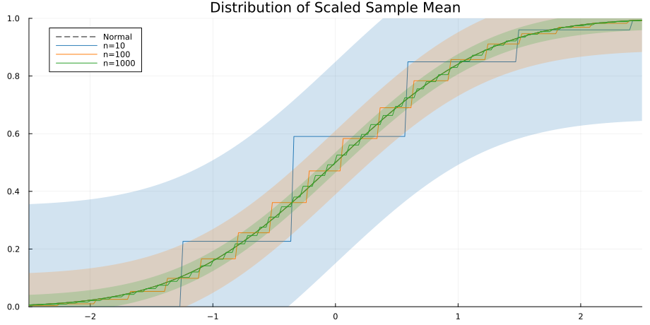

## Simulated Illustration of Berry-Esseen CLT : Slack Bounds

**plotting code**

```julia
unif = n->rand(n)*2sqrt(3) .- sqrt(3)
e3 = mean(abs.(unif(100_000)).^3)
plotcdfwithbounds(unif,e3)
```

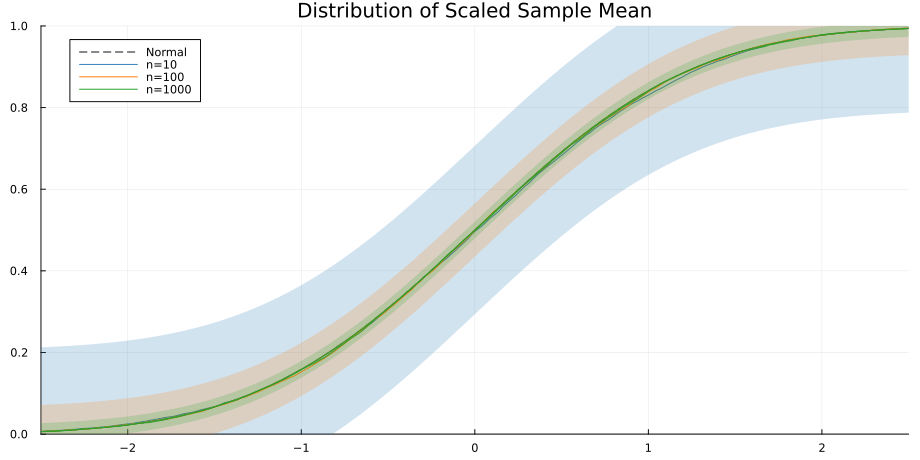

## High-Dimensional CLT

# References

Chernozhukov, Victor, Denis Chetverikov, and Yuta Koike. 2023. “Nearly optimal central limit theorem and bootstrap approximations in high dimensions.” *The Annals of Applied Probability* 33 (3): 2374–425. https://doi.org/10.1214/22-AAP1870.

Döbler, Christian. 2022. “A Short Proof of Lévy’s Continuity Theorem Without Using Tightness.” *Statistics & Probability Letters* 185: 109438. https://doi.org/https://doi.org/10.1016/j.spl.2022.109438.

Raič, Martin. 2019. “A multivariate Berry–Esseen theorem with explicit constants.” *Bernoulli* 25 (4A): 2824–53. https://doi.org/10.3150/18-BEJ1072.

Song, Kyunchul. 2021. *Introduction to Econometrics*.

Tao, Terence. 2010. *254A, Notes 2: The Central Limit Theorem*. https://terrytao.wordpress.com/2010/01/05/254a-notes-2-the-central-limit-theorem/.